# Pricing Coupon Bonds via Term-Structure Extraction

Extract an interest-rate term structure from market data and use it to value coupon bonds with transparency and rigour.

Fixed Income Yield Curve Bootstrapping Python

### Overview

- Goal: derive a term structure (zero curve / discount factors) and price coupon bonds consistently.
- Approach: bootstrap from market instruments → interpolate yields/discounts → compute present values of cash flows.

### Quick reference

- Instruments: swaps, bills, coupon bonds
- Interpolation: log-linear / maximum smoothness

# Import packages

```python
import pandas as pd
import numpy as np
from scipy.optimize import fsolve
from scipy.interpolate import interp1d
import matplotlib.pyplot as plt
```

# Data input

```python
df = pd.DataFrame(
    [
        {"Type": "BBSW", "Term": "1 month", "Rate": 4.06},
        {"Type": "BBSW", "Term": "3 months", "Rate": 4.17},
        {"Type": "BBSW", "Term": "6 months", "Rate": 4.50},
        {"Type": "Swap", "Term": "1 year", "Rate": 4.29},
        {"Type": "Swap", "Term": "3 years", "Rate": 4.06},
        {"Type": "Swap", "Term": "5 years", "Rate": 4.20},
        {"Type": "Swap", "Term": "10 years", "Rate": 4.45},
        {"Type": "Swap", "Term": "15 years", "Rate": 4.58},
    ]
)
df
```

|  | Type | Term | Rate |
| --- | --- | --- | --- |
| 0 | BBSW | 1 month | 4.06 |
| 1 | BBSW | 3 months | 4.17 |
| 2 | BBSW | 6 months | 4.50 |
| 3 | Swap | 1 year | 4.29 |
| 4 | Swap | 3 years | 4.06 |
| 5 | Swap | 5 years | 4.20 |
| 6 | Swap | 10 years | 4.45 |
| 7 | Swap | 15 years | 4.58 |

Note that the bank bill swap rate (BBSW) is quoted per annum with simple compounding, and "Swaps are quoted on a quarterly basis for maturities out to 3 years and on a semi-annual basis for maturities 4 years and greater." AFMA (2023), Interest Rate Derivative Conventions (see https://afma.com.au/getattachment/Standards/Market-Conventions/Sections/Content/Interest-Rate-Derivative-Conventions-2023-07.pdf?lang=en-AU )

# Term structure construction

## Boostrapping and log-linear interpolation

**Workflow**

- 🔍 Bootstrap short-end (BBSW) using money-market conventions.
- ⚖️ Solve swap PV equations to infer mid/long-term discount factors.
- 🧮 Log-linear Interpolate to fill the curve between pillars.
- 📐 Convert: discount factor term structure $B(0,t)$ ↔ spot instantaneous forward rate $f(0,t)$

**Outputs**

- discount factors D(t), and interpolated term-structure.

*Tip:* clearly state the compounding and day-count conventions used when publishing the curve.

$$ \begin{align*} \text{BBSW}(T) &= \frac{1}{T} \left( \frac{1}{B(0,T)} - 1 \right) \\ \text{Swap rate}(0,\mathbb{T}) &= \frac{1 - B(0,T_n)}{\sum_{i=1}^{N} (T_i - T_{i-1}) B(0,T_i)} \\ \end{align*} $$

Log-linear interpolation of discount factors: $$ \log B(0,t) = \log B(0,t_i) + \frac{t - t_i}{t_{i+1} - t_i} \left(\log B(0,t_{i+1}) - \log B(0,t_i)\right), \quad t \in [t_i, t_{i+1}] $$

```python
import re


def term_structure_constructor(df):
    new_df = pd.DataFrame(df)
    new_df["Term"] = [1 / 12, 1 / 4, 1 / 2, 1, 3, 5, 10, 15]
    new_df["Rate"] = new_df["Rate"] / 100

    def target_func(x):
        B = np.array([1] + list(x))
        B = np.log(B)
        T = np.array([0] + list(new_df["Term"]))
        interp = interp1d(T, B, kind="linear", fill_value="interpolate")

        def log_lin(t):
            return np.exp(interp(t))

        equations = []
        for i in range(len(new_df)):
            if new_df.iloc[i, 0] == "BBSW":
                equations.append(
                    (1 / log_lin(new_df.iloc[i, 1]) - 1) / new_df.iloc[i, 1]
                    - new_df.iloc[i, 2]
                )
            else:
                T_i = new_df.iloc[i, 1]
                rate = new_df.iloc[i, 2]
                freq = 1 / 4 if T_i <= 3 else 1 / 2
                payments = np.arange(freq, T_i + freq, freq)
                sum_dfs = np.sum([log_lin(t) for t in payments])
                equations.append((1 - log_lin(T_i)) / (freq * sum_dfs) - rate)
        return equations

    B = fsolve(target_func, [0.95] * len(new_df))
    B = np.array([1] + list(B))
    B = np.log(B)
    T = np.array([0] + list(new_df["Term"]))
    interp = interp1d(T, B, kind="linear", fill_value="interpolate")

    def log_lin(t):
        return np.exp(interp(t))

    # prepend a zero-term row (time 0, DF = 1 implicitly via interpolation)
    new_row = pd.DataFrame([{"Type": "Cash", "Term": 0.0, "Rate": 0.0}])
    new_df = pd.concat([new_row, new_df], ignore_index=True)
    new_df["Discount Factor"] = [log_lin(t) for t in new_df["Term"]]

    def ifr_calculator(t):
        idx_start = new_df[new_df["Term"] <= t].index[-1]
        if idx_start == len(new_df) - 1:
            idx_start -= 1
        T1 = new_df.loc[idx_start, "Term"]
        T2 = new_df.loc[idx_start + 1, "Term"]
        B1 = np.log(new_df.loc[idx_start, "Discount Factor"])
        B2 = np.log(new_df.loc[idx_start + 1, "Discount Factor"])
        slope = (B2 - B1) / (T2 - T1)
        return -slope

    return log_lin, new_df, ifr_calculator
```

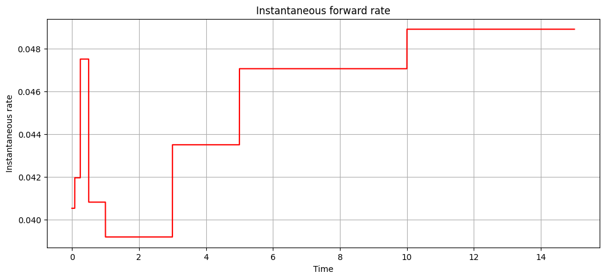

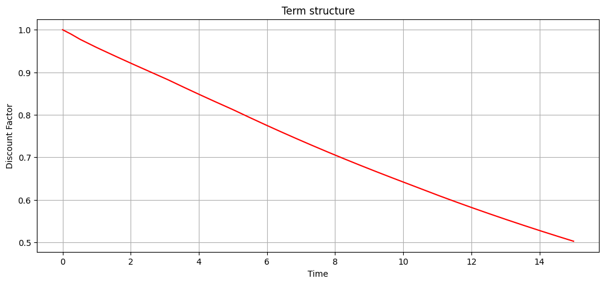

```
Term structure is define by the given zero counpon bonds price below:
```

|  | Type | Term | Rate | Discount Factor |
| --- | --- | --- | --- | --- |
| 0 | Cash | 0.000000 | 0.0000 | 1.000000 |
| 1 | BBSW | 0.083333 | 0.0406 | 0.996628 |
| 2 | BBSW | 0.250000 | 0.0417 | 0.989683 |
| 3 | BBSW | 0.500000 | 0.0450 | 0.977995 |
| 4 | Swap | 1.000000 | 0.0429 | 0.958237 |
| 5 | Swap | 3.000000 | 0.0406 | 0.886004 |
| 6 | Swap | 5.000000 | 0.0420 | 0.812171 |
| 7 | Swap | 10.000000 | 0.0445 | 0.641859 |
| 8 | Swap | 15.000000 | 0.0458 | 0.502594 |

```
Any discount factor at the time in range [0,15] will be calculated via log-linear interpolation of the 2 closest zero counpon bonds on both side of the time in the above table
```

```python
df_calculator_1, term_structure, ifr_calculator_1 = term_structure_constructor(df)
t = np.arange(0, 15, 1 / 1000)
dfs = list(map(lambda x: df_calculator_1(x), t))
irf_1 = list(map(lambda x: ifr_calculator_1(x), t))
plt.figure(figsize=(12, 5))
plt.plot(t, irf_1, linestyle="-", color="r", label="Instantaneous Rate")
plt.title("Instantaneous forward rate")
plt.xlabel("Time")
plt.ylabel("Instantaneous rate")
plt.grid(True)
plt.show()

plt.figure(figsize=(12, 5))
plt.plot(t, dfs, linestyle="-", color="r")
plt.title("Term structure")
plt.xlabel("Time")
plt.ylabel("Discount Factor")
plt.grid(True)
plt.show()
print("Term structure is define by the given zero counpon bonds price below:")
display(term_structure)
print(
    "Any discount factor at the time in range [0,15] will be calculated via log-linear interpolation of the 2 closest zero counpon bonds on both side of the time in the above table"
)
```

## Maximum smoothness

### Constructing the Term Structure via Maximum Smoothness

The **maximum-smoothness approach** constructs an instantaneous forward-rate curve $f(0,t)$ that both fits market instruments and minimises unnecessary curvature. This ensures a stable, arbitrage-free, and visually smooth term structure.

### Smoothness Objective

We select the forward curve that minimises the integral of squared curvature:

$$ \min_{f} \int_{0}^{T} \left(f''(0,s)\right)^2\,ds. $$

This penalises rapid oscillations and ensures the smoothest curve consistent with market data.

### Forward Curve Representation

Let the market provide discount factors at knot points

$$ 0 = t_0 < t_1 < \dots < t_m < t_{m+1} = T. $$

The maximum-smoothness solution (Vasicek spline) implies that on each interval:

$$ f(0,t) = c_i t^4 + b_i t + a_i, \qquad t_{i-1} < t \le t_i. $$

This is a **piecewise quartic polynomial** with no quadratic or cubic terms, resulting from the Euler–Lagrange solution of the variational problem.

### Constraints

To ensure global smoothness and exact market fit, the coefficients ((a_i,b_i,c_i)) satisfy:

#### 1. Continuity of the forward rate

$$ c_i t_i^4 + b_i t_i + a_i = c_{i+1} t_i^4 + b_{i+1} t_i + a_{i+1}. $$

#### 2. Continuity of the slope

$$ 4c_i t_i^3 + b_i = 4c_{i+1} t_i^3 + b_{i+1}. $$

#### 3. Exact fit to discount factors

For each maturity $t_i$, $$ \int_{t_{i-1}}^{t_i} f(0,s)\,ds = -\log \frac{B(0,t_i)}{B(0,t_{i-1})}. $$

Expanding the integral gives: $$ \frac{1}{5}c_i(t_i^5 - t_{i-1}^5) + \frac{1}{2}b_i(t_i^2 - t_{i-1}^2) + a_i (t_i - t_{i-1}) = -\log \frac{B(0,t_i)}{B(0,t_{i-1})}. $$

#### 4. Terminal smoothness

$$ c_{m+1} = 0. $$

Common additional conditions:

- **Flat terminal slope:** $ f'(0,T) = 0 \Rightarrow b_{m+1} = 0. $
- **Known short rate:** $ a_1 = r(0). $

These yield a fully determined linear system for all coefficients.

### Using Swap Rates Instead of Discount Factors

If the inputs are swap rates $ \ell(0,t_i) $ rather than zero-coupon prices, the pricing constraint becomes nonlinear:

$$ 1 = e^{-\int_0^{t_i} f(0,s)\,ds} + \ell(0,t_i)\sum_{j=1}^{i} e^{-\int_0^{t_j} f(0,s)\,ds}. $$

This transforms the calibration into a **fixed-point problem**, but the smoothness and continuity constraints remain identical.

### Summary

- The maximum-smoothness approach produces the smoothest instantaneous forward curve consistent with observed prices.
- The optimal curve is a **piecewise quartic spline**.
- Forward-rate continuity, slope continuity, and pricing constraints uniquely determine the spline coefficients.
- Swap-rate inputs require a nonlinear solver; discount factors yield a linear one.

This method is widely used in fixed-income modelling due to its stability and arbitrage-free construction.

```python
def smoothness_constructor(df, term_structure):
    new_df = pd.DataFrame(df)
    new_df["Term"] = [1 / 12, 1 / 4, 1 / 2, 1, 3, 5, 10, 15]
    new_df["Rate"] = new_df["Rate"] / 100
    points = len(new_df)
    BBSW = new_df[new_df["Type"] == "BBSW"].reset_index(drop=True)
    Swap = new_df[new_df["Type"] == "Swap"].reset_index(drop=True)

    def solve(p):
        results = []
        a = p[:points]
        b = p[points : 2 * points]
        c = p[2 * points :]

        # Condition 1
        for i in range(points - 1):
            t = new_df.iloc[i, 1]
            results.append(
                (c[i] * (t**4) + b[i] * t + a[i])
                - (c[i + 1] * (t**4) + b[i + 1] * t + a[i + 1])
            )

        # Condition 2
        for i in range(points - 1):
            t = new_df.iloc[i, 1]
            results.append(
                (4 * c[i] * (t**3) + b[i]) - (4 * c[i + 1] * (t**3) + b[i + 1])
            )

        # Condition 3
        results.append(b[-1])
        results.append(a[0] - new_df.iloc[0, 2])

        # Condition 4
        for i in range(len(BBSW)):
            ti = BBSW.iloc[i, 1]
            t = BBSW.iloc[i - 1, 1] if i != 0 else 0
            B_prev = (
                1 if i == 0 else (1 / (1 + BBSW.iloc[i - 1, 2] * BBSW.iloc[i - 1, 1]))
            )
            B_curr = 1 / (1 + BBSW.iloc[i, 2] * BBSW.iloc[i, 1])
            results.append(
                (1 / 5) * c[i] * ((ti**5) - (t**5))
                + (1 / 2) * b[i] * ((ti**2) - (t**2))
                + a[i] * (ti - t)
                + np.log(B_curr / B_prev)
            )

        def inside_instant_calculator(t):
            T = list(new_df["Term"])
            ts = [0] + list(filter(lambda x: x < t, T)) + [t]
            sum = 0
            for i in range(len(ts) - 1):
                sum += (
                    (1 / 5) * c[i] * (ts[i + 1] ** 5 - ts[i] ** 5)
                    + (1 / 2) * b[i] * (ts[i + 1] ** 2 - ts[i] ** 2)
                    + a[i] * (ts[i + 1] - ts[i])
                )
            return sum

        for i in range(len(Swap)):
            t = Swap.iloc[i, 1]
            freq = 1 / 4 if t <= 3 else 1 / 2
            payments = np.arange(freq, t, freq)
            l = Swap.iloc[i, 2] * freq
            sum_dfs = sum(
                list(map(lambda x: np.exp(-inside_instant_calculator(x)), payments))
            )
            results.append(
                inside_instant_calculator(t) + np.log((1 - l * sum_dfs) / (1 + l))
            )

        return results

    p = fsolve(solve, [100] * len(new_df) * 3)
    a = p[:points]
    b = p[points : 2 * points]
    c = p[2 * points :]
    T = list(new_df["Term"])

    def ifr_calculator(t):
        i = len(list(filter(lambda x: x < t, T)))
        return c[i] * (t**4) + b[i] * t + a[i]

    def df_calculator(t):
        ts = [0] + list(filter(lambda x: x < t, T)) + [t]
        sum = 0
        for i in range(len(ts) - 1):
            sum += (
                (1 / 5) * c[i] * (ts[i + 1] ** 5 - ts[i] ** 5)
                + (1 / 2) * b[i] * (ts[i + 1] ** 2 - ts[i] ** 2)
                + a[i] * (ts[i + 1] - ts[i])
            )
        return np.exp(-sum)

    return ifr_calculator, df_calculator
```

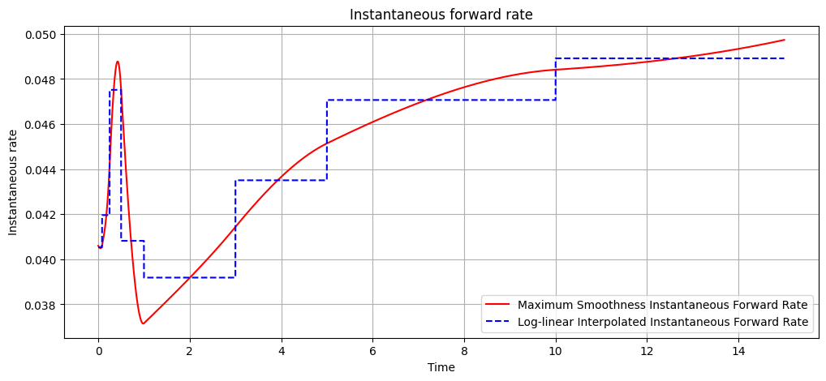

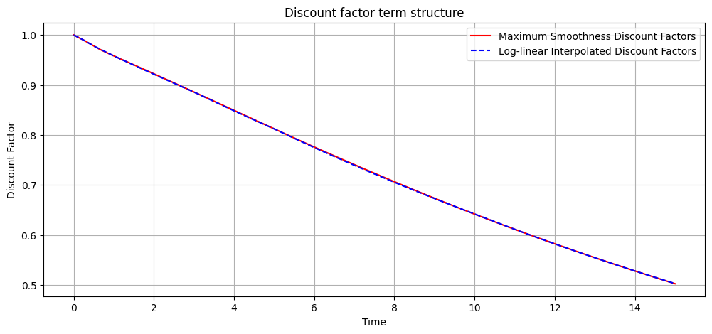

```python
ifr_calculator, df_calculator_2 = smoothness_constructor(df, term_structure)
t = np.arange(0, 15, 1 / 1000)
irf_2 = list(map(lambda x: ifr_calculator(x), t))
plt.figure(figsize=(12, 5))
plt.plot(
    t,
    irf_2,
    linestyle="-",
    color="r",
    label="Maximum Smoothness Instantaneous Forward Rate",
)
plt.plot(
    t,
    irf_1,
    linestyle="--",
    color="b",
    label="Log-linear Interpolated Instantaneous Forward Rate",
)
plt.title("Instantaneous forward rate")
plt.xlabel("Time")
plt.ylabel("Instantaneous rate")
plt.grid(True)
plt.legend()
plt.show()

discount_factors = list(map(lambda x: df_calculator_2(x), t))
plt.figure(figsize=(12, 5))
plt.plot(
    t,
    discount_factors,
    linestyle="-",
    color="r",
    label="Maximum Smoothness Discount Factors",
)
plt.plot(
    t, dfs, linestyle="--", color="b", label="Log-linear Interpolated Discount Factors"
)
plt.legend()
plt.title("Discount factor term structure")
plt.xlabel("Time")
plt.ylabel("Discount Factor")
plt.grid(True)
plt.show()
```

From the plot, it can be seen that the maximum smoothness instantaneous forward rate curve is very smooth without abrupt changes compared to the log-linear interpolated instantaneous forward rate curve. This is because the maximum smoothness method minimises the curvature of the instantaneous forward rate curve, resulting in a smoother and more stable curve. In contrast, the log-linear interpolation method may introduce abrupt changes in the instantaneous forward rate curve due to its piecewise linear nature. Furthermore, the maximum smoothness also tracks the overall trend of the instantaneous forward rate curve used by log-linear interpolation.

For the discount factor term structure, both methods produce very similar results, as the discount factors are derived from the instantaneous forward rates. The small differences observed are due to the different interpolation techniques used in each method.

# Pricing coupon bond

Consider a coupon bond with a principal of 100 and a coupon rate of 8% per annum, where the bond matures in exactly five years and the coupons are paid quarterly.

```python
def bond_value_calc(F, c, freq, T):
    payments = np.arange(freq, freq + T, freq)
    B1 = list(map(lambda x: df_calculator_1(x), payments))
    B2 = list(map(lambda x: df_calculator_2(x), payments))
    return (
        np.sum(np.array(B1)) * c * freq * F + B1[-1] * F,
        np.sum(np.array(B2)) * c * freq * F + B2[-1] * F,
    )
```

```python
value_1, value_2 = bond_value_calc(100, 0.08, 1 / 4, 5)
print("Value under Task 1 structure: ", value_1)
print("Value under Task 2 structure: ", value_2)
```

```
Value under Task 1 structure:  117.18242826569126
Value under Task 2 structure:  117.18980599957409
```

We can see that the bond price calculated using the maximum smoothness term structure is slightly higher than that calculated using the log-linear interpolation method. This is because the maximum smoothness method produces a smoother and more realistic term structure, which can lead to higher present values for future cash flows than the log-linear interpolation method, which may introduce abrupt changes in discount factors between pillars.